# Bike Share Prediction

Shengao Yi

2022-11-04

## 1. Introduction

Over the past few years, with the growing prosperity of the sharing economy, the shared transportation systems like bikes, scooters, have become a common phenomenon in the United States. As a part of public transportation, shared bikes play a significant role in helping people to finish the “last mile trip”. The famous “last mile” issue in transportation is that commuters and travellers find it difficult to reach their final destination from a transportation hub such as subway, bus, and railway stations. Bike-sharing platforms can help solve the last mile problem and provide a good mobility option, especially for short-distance travellers. It can also encourage people to Green Travel and Low-Carbon Life.

On the other hand, sharing bikes are still facing many problems, one of the most difficult problems is the need to “re-balance” bicycles across the network. It’s extremely hard for sharing bike companies to predict bike share demand for all docks at all time. Bike share is not useful if a dock has no bikes to pickup, nor if there are no open docking spaces to deposit a bike. The strategies for the companies are often allocating the bikes randomly, which is pretty inefficient. Thus, this project proposes a data-driven spatio-temporal model to predict the demand for bikes in service areas.

The study area is Washington DC, the capital of United States. We have collected about 464,000 bike trips data (5 weeks) from June to July, 2022. We assume that the variation of bike trips is a function of historical time and spatial patterns. By creating the time and space lag, the regression would use the historical behavior to predict the future ridership, which is similar as the Long Short-Term Memory (LSTM) algorithm in Deep Learning. We use stations as basic analysis unit and set 15-minutes and 60-minutes intervals. In addition, our regression model also takes weather conditions, urban facilities into consideration, and by controlling different variables as predictors, we compare and test the accuracy and generalizability for different models. At last, we can use the spatio-temporal model to predict the following one hour demand at any given time.

To make the model more effective, we can also introduce some rewards strategies such as: If we know the demand, capacity of each dock and the user’s destination, we can incentivize them to drop off the bike to another nearby high-demand and low-capacity dock, supply some discounts as a reward. This would be a win-win system.

```r
Sys.setlocale("LC_TIME", "English")
```

```
## [1] "English_United States.1252"
```

```r
# Rmarkdown global setting
knitr::opts_chunk$set(echo = TRUE)
knitr::opts_chunk$set(message = FALSE)
knitr::opts_chunk$set(warning = FALSE)
knitr::opts_chunk$set(cache = TRUE)
knitr::opts_chunk$set(fig.align = 'center')

library(tidyverse)
library(sf)
library(lubridate)
library(tigris)
library(tidycensus)
library(viridis)
library(riem)
library(gridExtra)
library(knitr)
library(kableExtra)
library(RSocrata)
library(FNN)
library(caret)
library(gganimate)
library(gifski)

options(tigris_class = "sf")
source("https://raw.githubusercontent.com/urbanSpatial/Public-Policy-Analytics-Landing/master/functions.r")

palette5 <- c("#eff3ff","#bdd7e7","#6baed6","#3182bd","#08519c")
palette4 <- c("#D2FBD4","#92BCAB","#527D82","#123F5A")
palette2 <- c("#6baed6","#08519c")

plotTheme <- theme(
  plot.title =element_text(size=12),
  plot.subtitle = element_text(size=8),
  plot.caption = element_text(size = 6),
  axis.text.x = element_text(size = 10, angle = 45, hjust = 1),
  axis.text.y = element_text(size = 10),
  axis.title.y = element_text(size = 10),
  # Set the entire chart region to blank
  panel.background=element_blank(),
  plot.background=element_blank(),
  #panel.border=element_rect(colour="#F0F0F0"),
  # Format the grid
  panel.grid.major=element_line(colour="#D0D0D0",size=.2),
  axis.ticks=element_blank())


mapTheme <- function(base_size = 10, title_size = 12, small_size = 8) {
  theme(
    text = element_text( color = "black"),
    plot.title = element_text(size = title_size, colour = "black", hjust = 0.5),
    plot.subtitle=element_text(size = base_size, colour = "black", hjust = 0.5, face="italic"),
    plot.caption=element_text(size = small_size, colour = "black", hjust = 0.5),
    axis.ticks = element_blank(),
    axis.title = element_blank(),
    axis.text = element_blank(),
    axis.title.x = element_blank(),
    axis.title.y = element_blank(),
    panel.background = element_blank(),
    panel.grid.minor = element_blank(),
    panel.border = element_blank(),
    strip.text.x = element_text(size = base_size),
    strip.text.y = element_text(size = base_size),
    strip.background = element_rect(colour="transparent", fill="transparent"),
    legend.title = element_text(size = small_size),
    legend.text = element_text(size = small_size),
    legend.key.size = unit(0.4, "cm"))
}
# mapTheme <- theme(plot.title =element_text(size=12),
#                   plot.subtitle = element_text(size=8),
#                   plot.caption = element_text(size = 6),
#                   axis.line=element_blank(),
#                   axis.text.x=element_blank(),
#                   axis.text.y=element_blank(),
#                   axis.ticks=element_blank(),
#                   axis.title.x=element_blank(),
#                   axis.title.y=element_blank(),
#                   panel.background=element_blank(),
#                   panel.border=element_blank(),
#                   panel.grid.major=element_line(colour = 'transparent'),
#                   panel.grid.minor=element_blank(),
#                   legend.direction = "vertical",
#                   legend.position = "right",
#                   plot.margin = margin(1, 1, 1, 1, 'cm'),
#                   legend.key.height = unit(1, "cm"), legend.key.width = unit(0.2, "cm"))
```

## 2. Data Wrangling

In this project, we mainly use four types of data to construct the final spatio-temporal model:

- **Washington DC Bikeshare Data**: collected the data from Open Data DC (https://opendata.dc.gov/), which includes all the shared bike trips in June and July, 2022 with 783,339 records in total. The data has some attribute fields like start time, end time, start longitude, start latitude and so on.
- **Washington DC Weather Data**: collected from Ronald Reagan Washington National Airport. It’s close to DC, so it can represent the local weather conditions in DC. It contains three weather features: temperature, precipitation, and wind speed.
- **Census Data**: collected from tidycensus. It contains some socio-economic characteristics like total population, medium household income, white population and so on.
- **Urban Facilities**: collected bus stations, metro stations, parks, universities & colleges point data from Open Data DC. These facilities may have a strong relationship with shared bike trips.

### 2.1 Bikeshare Data

We have imported the two months bikeshare data, and selected five weeks from the original data, then created 15-minute and 60-minute intervals, also identified day of week for later research.

```r
# Bike Share Data

DC_bike <-
  rbind(read.csv("./Data/202206-capitalbikeshare.csv"),
        read.csv("./Data/202207-capitalbikeshare.csv")) %>%
  mutate(interval60 = floor_date(ymd_hms(started_at), unit = "hour"),
         interval15 = floor_date(ymd_hms(started_at), unit = "15 mins"),
         week = week(interval60),
         dotw = wday(interval60, label=TRUE)) %>%
  filter(week > 22 & week <= 27)
```

### 2.2 Census Data

The census tracts of the Washington DC and their socio-economic features are obtained through tidycensus. We have extracted the geometric information of tracts and shown in the figure below.

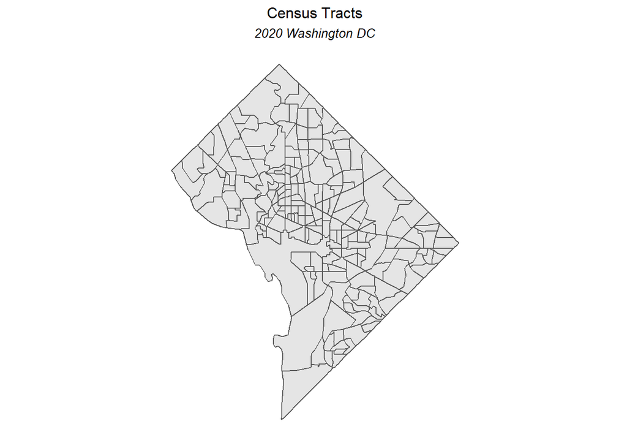

```r
# Neighborhood Data
DC_neighborhood <-
  st_read("./Data/Neighborhood.geojson") %>%
  st_transform('ESRI:102685')

# Washington, DC Census Data 2020
census_api_key("155cc525674a0d27c98afbb7030d0802e9bb5543", overwrite = TRUE)

DC_tracts <-
  get_acs(geography = "tract",
          variables = c("B01003_001", "B19013_001",
                        "B02001_002", "B08013_001",
                        "B08012_001", "B08301_001",
                        "B08301_010", "B01002_001",
                        "B08301_018"),
          year=2020,
          state=11,
          geometry=T,
          output="wide") %>%
  st_transform('ESRI:102685') %>% # using the state plane of Maryland for a projection
  rename(Total_Pop =  B01003_001E,
         Med_Inc = B19013_001E,
         Med_Age = B01002_001E,
         White_Pop = B02001_002E,
         Travel_Time = B08013_001E,
         Num_Commuters = B08012_001E,
         Means_of_Transport = B08301_001E,
         Total_Public_Trans = B08301_010E,
         Total_Bike = B08301_018E) %>%
  select(Total_Pop, Med_Inc, White_Pop, Travel_Time,
         Means_of_Transport, Total_Public_Trans,
         Med_Age, Total_Bike,
         GEOID, geometry) %>%
  mutate(Percent_White = White_Pop / Total_Pop,
         Mean_Commute_Time = Travel_Time / Total_Public_Trans,
         Percent_Taking_Public_Trans = Total_Public_Trans / Means_of_Transport,
         Percent_Taking_bike = Total_Bike / Means_of_Transport)

# Extract geometries
DC_tracts <-
  DC_tracts %>%
  as.data.frame() %>%
  distinct(GEOID, .keep_all = TRUE) %>%
  select(GEOID, geometry) %>%
  st_sf

ggplot() +
  geom_sf(data = DC_tracts) +
  labs(title = "Census Tracts",
       subtitle = "2020 Washington DC") +
  mapTheme()
```

### 2.3 Weather Data

The weather condition can easily affect riders. So it’s important for us to take weather into consideration.

The following figure shows the three attributes of the weather over 5 weeks. It can be seen that precipitation is relatively stable, except for 23 June. On that day, the temperature and wind speed also decreased suddenly.

```r
weather.Panel <-
  riem_measures(station = "DCA", date_start = "2022-06-04", date_end = "2022-07-08") %>%
  dplyr::select(valid, tmpf, p01i, sknt)%>%
  replace(is.na(.), 0) %>%
    mutate(interval60 = ymd_h(substr(valid,1,13))) %>%
    mutate(week = week(interval60),
           dotw = wday(interval60, label=TRUE)) %>%
    group_by(interval60) %>%
    summarize(Temperature = max(tmpf),
              Precipitation = sum(p01i),
              Wind_Speed = max(sknt)) %>%
    mutate(Temperature = ifelse(Temperature == 0, 42, Temperature))
```

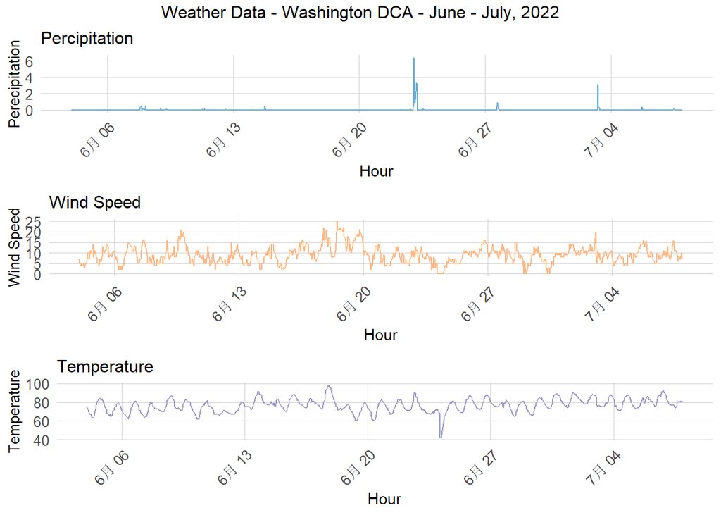

```r
grid.arrange(
  ggplot(weather.Panel, aes(interval60,Precipitation)) +
    geom_line(color = '#6baed6') +
  labs(title="Percipitation", x="Hour", y="Perecipitation") +
    plotTheme,
  ggplot(weather.Panel, aes(interval60,Wind_Speed)) +
    geom_line(color = '#FEB984') +
    labs(title="Wind Speed", x="Hour", y="Wind Speed") +
    plotTheme,
  ggplot(weather.Panel, aes(interval60,Temperature)) +
    geom_line(color = '#9e9ac8') +
    labs(title="Temperature", x="Hour", y="Temperature") +
    plotTheme,
  top="Weather Data - Washington DCA - June - July, 2022")
```

### 2.4 Merge Census Data with the Bikeshare Data

In this section, we merge census data with bikeshare data by their geospatial location relationship.

```r
## Add census data to bikeshare data

DC_Bike_Census <- st_join(DC_bike %>%
                            filter(is.na(start_lng) == FALSE &
                                     is.na(start_lat) == FALSE &
                                     is.na(end_lat) == FALSE &
                                     is.na(end_lng) == FALSE) %>%
                            st_as_sf(., coords = c("start_lng", "start_lat"), crs = 4326),
    DC_tracts %>%
      st_transform(crs=4326),
    join=st_intersects, left = TRUE) %>%
  rename(Origin.Tract = GEOID) %>%
  mutate(start_lng = unlist(map(geometry, 1)),
         start_lat = unlist(map(geometry, 2)))%>%
  as.data.frame() %>%
  select(-geometry) %>%
  st_as_sf(., coords = c("end_lng", "end_lat"), crs = 4326) %>%
  st_join(., DC_tracts %>%
            st_transform(crs=4326),
          join=st_intersects,
          left = TRUE) %>%
  rename(Destination.Tract = GEOID)  %>%
  mutate(end_lng = unlist(map(geometry, 1)),
         end_lat = unlist(map(geometry, 2)))%>%
  as.data.frame() %>%
  select(-geometry) %>%
  na.omit()
```

### 2.5 Create final space-time panel

In this project, we create panels for start points and consider spatio-temporal patterns. The basic unit is based on stations. Every row in the panel represent a time period, whether there is an observation or not. So even if the station has no trips, the number is still zero.

Firstly, we create an empty data frame “study.panel” using the expand.grid function and unique. Then, we join the station, longitude, latitude and some other information together. A time lag is a fairly long interval of time between one event and another related event that happens after it. We created different time lags of 1, 2, 3, 4, 12, and one day,

```r
study.panel <-
  expand.grid(interval60=unique(DC_Bike_Census$interval60),
              start_station_id = unique(DC_Bike_Census$start_station_id)) %>%
  left_join(., DC_Bike_Census %>%
              select(start_station_id, start_station_name, Origin.Tract, start_lng, start_lat)%>%
              distinct() %>%
              group_by(start_station_id) %>%
              slice(1))

# Rider panel

ride.panel <-
  DC_Bike_Census %>%
  mutate(Trip_Counter = 1) %>%
  right_join(study.panel) %>%
  group_by(interval60, start_station_id, start_station_name, Origin.Tract, start_lng, start_lat) %>%
  summarize(Trip_Count = sum(Trip_Counter, na.rm=T)) %>%
  left_join(weather.Panel) %>%
  ungroup() %>%
  filter(is.na(start_station_id) == FALSE) %>%
  mutate(week = week(interval60),
         dotw = wday(interval60, label = TRUE)) %>%
  filter(is.na(Origin.Tract) == FALSE)

ride.panel <-
  left_join(ride.panel, DC_tracts %>%
              as.data.frame() %>%
              select(-geometry), by = c("Origin.Tract" = "GEOID"))
# Time lags

ride.panel <-
  ride.panel %>%
  arrange(start_station_id, interval60) %>%
  mutate(lagHour = dplyr::lag(Trip_Count,1),
         lag2Hours = dplyr::lag(Trip_Count,2),
         lag3Hours = dplyr::lag(Trip_Count,3),
         lag4Hours = dplyr::lag(Trip_Count,4),
         lag12Hours = dplyr::lag(Trip_Count,12),
         lag1day = dplyr::lag(Trip_Count,24)) %>%
  mutate(day = yday(interval60))

ride.panel <-
  ride.panel %>%
  mutate(X = start_lng, Y = start_lat)%>%
  st_as_sf(coords = c("X", "Y"), crs = 4326, agr = "constant") %>%
  st_transform('ESRI:102685')
```

### 2.6 Urban facilities data and features engineering

We collected parks, bus stations, metro stations, universities & colleges data, and calculated the mean distance of the each nearest facility for each trip record.

```r
# Parks
DC_parks <-
  st_read("./Data/Parks_and_Recreation_Areas.geojson") %>%
  dplyr::select(geometry) %>%
  st_transform('ESRI:102685') %>%
  mutate(Legend = "Park")

DC_parks <-
  DC_parks[DC_tracts,]

# Distance to Park
ride.panel <-
  ride.panel %>%
  mutate(park_dist = nn_function(st_coordinates(ride.panel), st_coordinates(st_centroid(DC_parks)), 1))

# Metro Stops
DC_metro <-
  st_read("./Data/Metro_Stations_Regional.geojson") %>%
  dplyr::select(geometry) %>%
  st_transform('ESRI:102685') %>%
  mutate(Legend = "Metro")

# Bus Stops
DC_bus <-
  st_read("./Data/Commuter_Bus_Stops.geojson") %>%
  dplyr::select(geometry) %>%
  st_transform('ESRI:102685') %>%
  mutate(Legend = "Bus")

DC_stops <-
  rbind(DC_metro, DC_bus)

DC_stops <-
  DC_stops[DC_tracts,]

# Distance to transit stop
ride.panel <-
  ride.panel %>%
  mutate(stop_dist = nn_function(st_coordinates(ride.panel), st_coordinates(st_centroid(DC_stops)), 1))

# Universities & Colleges
DC_universities <-
  st_read("./Data/Universities_and_Colleges.geojson") %>%
  dplyr::select(geometry) %>%
  st_transform('ESRI:102685') %>%
  mutate(Legend = "University")

DC_universities <-
  DC_universities[DC_tracts,]

# Distance to universities
ride.panel <-
  ride.panel %>%
  mutate(university_dist = nn_function(st_coordinates(ride.panel), st_coordinates(DC_universities), 1))
```

## 3. Exploratory Analysis

In this section, we firstly analyze the change of trips data from two perspectives: spatio-temporal.

### 3.1 Trip variation cross time

Firstly, we have counted the number of trips per hour during the study time. It can be seen that the trips have a periodic pattern every week, and the curves within a day are similar.

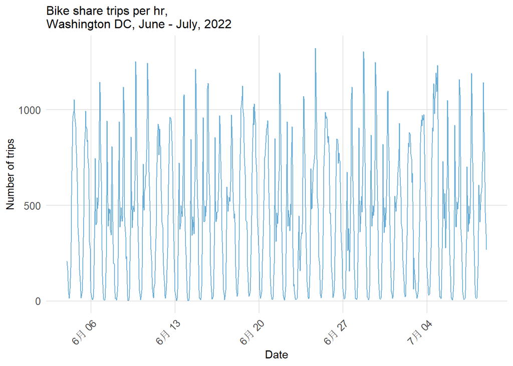

```r
ggplot(DC_Bike_Census %>%
         group_by(interval60) %>%
         tally())+
  geom_line(aes(x = interval60, y = n), color = '#6baed6')+
  labs(title="Bike share trips per hr,\nWashington DC, June - July, 2022",
       x="Date",
       y="Number of trips")+
  plotTheme
```

Let’s keep the time scale to one day, classified into four categories: Overnight, AM Rush, Mid-Day and PM Rush. We calculated mean number of hourly trips. From the figure below, we can find that there are fewer trips in the mid night and morning than the noon or afternoon. It seems that people are more likely to use bike after work.

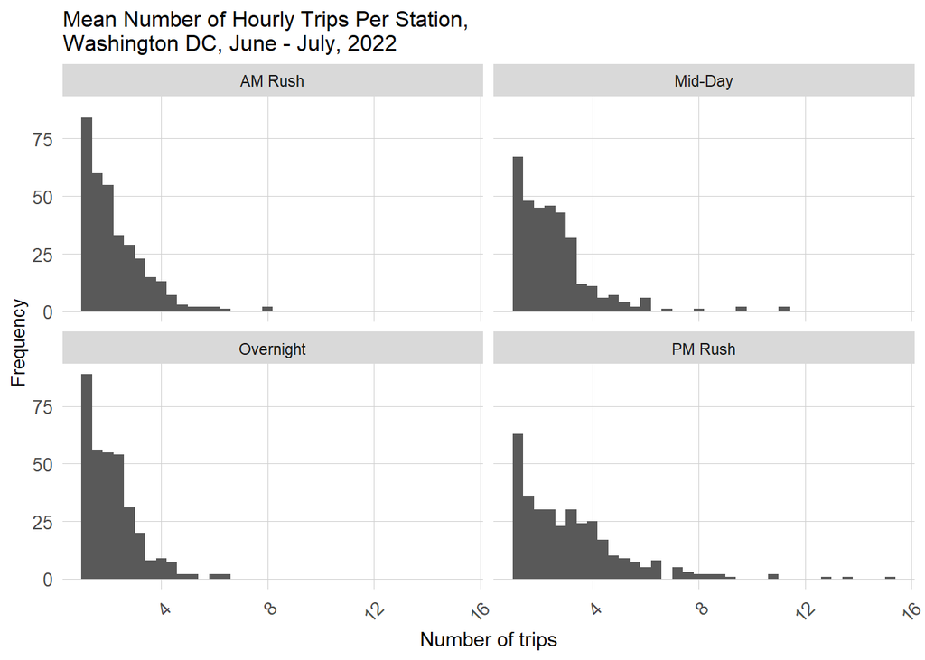

```r
# Mean number of hourly trips
DC_Bike_Census %>%
  mutate(time_of_day = case_when(hour(interval60) < 7 | hour(interval60) > 18 ~ "Overnight",
                                 hour(interval60) >= 7 & hour(interval60) < 10 ~ "AM Rush",
                                 hour(interval60) >= 10 & hour(interval60) < 15 ~ "Mid-Day",
                                 hour(interval60) >= 15 & hour(interval60) <= 18 ~ "PM Rush")) %>%
  group_by(interval60, start_station_name, time_of_day) %>%
  tally()%>%
  group_by(start_station_name, time_of_day)%>%
  summarize(mean_trips = mean(n))%>%
  ggplot()+
  geom_histogram(aes(mean_trips), binwidth = 0.4)+
  labs(title="Mean Number of Hourly Trips Per Station,\nWashington DC, June - July, 2022",
       x="Number of trips",
       y="Frequency")+
  facet_wrap(~time_of_day)+
  plotTheme
```

```r
# By station

# ggplot(DC_Bike_Census %>%
#          group_by(interval60, start_station_name) %>%
#          tally())+
#   geom_histogram(aes(n), binwidth = 2)+
#   labs(title="Bike trips per hr by station,\nWashington DC, June - July, 2022",
#        x="Number of Stations",
#        y="Trip Counts")+
#   plotTheme
```

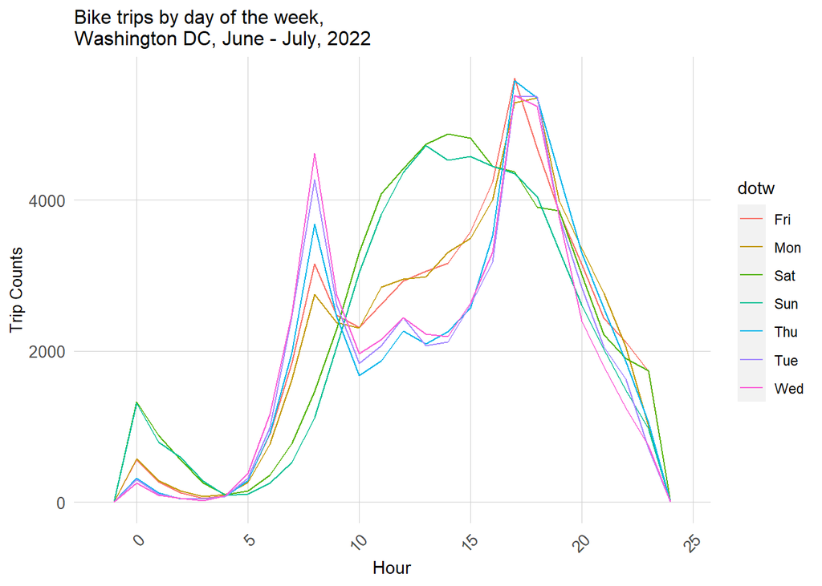

```r
## Number of trips by hour in a week
ggplot(DC_Bike_Census %>%
         mutate(hour = hour(started_at)))+
  geom_freqpoly(aes(hour, color = dotw), binwidth = 1)+
  labs(title="Bike trips by day of the week,\nWashington DC, June - July, 2022",
       x="Hour",
       y="Trip Counts")+
  plotTheme
```

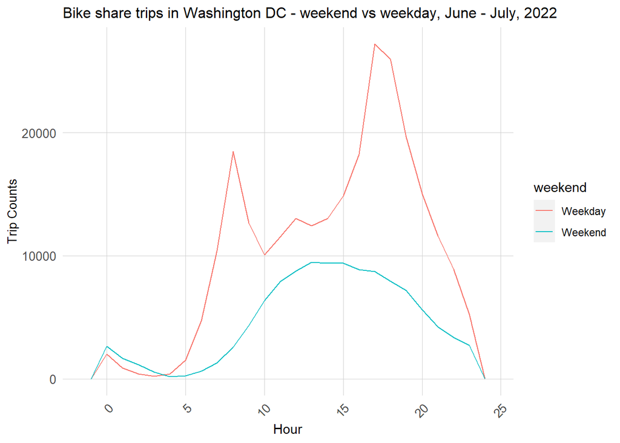

```r
ggplot(DC_Bike_Census %>%
         mutate(hour = hour(started_at),
                weekend = ifelse(dotw %in% c("Sun", "Sat"), "Weekend", "Weekday")))+
     geom_freqpoly(aes(hour, color = weekend), binwidth = 1)+
  labs(title="Bike share trips in Washington DC - weekend vs weekday, June - July, 2022",
       x="Hour",
       y="Trip Counts")+
     plotTheme
```

Following is the trip’s duration distribution, most durations of trips are around 7-8 minutes, then gradually decrease.

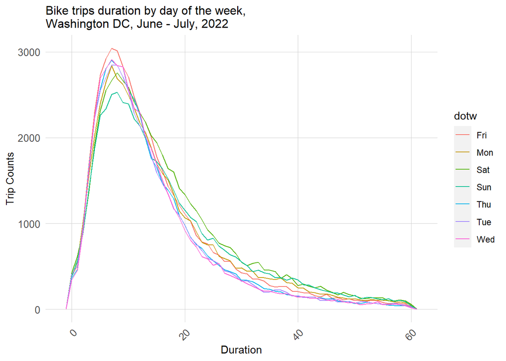

```r
## Number of trips by duration in a week

DC_Bike_Census$duration <-
  as.numeric(difftime(strptime(DC_Bike_Census$ended_at, "%Y-%m-%d %H:%M:%S"), strptime(DC_Bike_Census$started_at, "%Y-%m-%d %H:%M:%S"), unit = "mins"))

ggplot(subset(DC_Bike_Census, duration < 60 & duration > 0))+
  geom_freqpoly(aes(duration, color = dotw), binwidth = 1)+
  labs(title="Bike trips duration by day of the week,\nWashington DC, June - July, 2022",
       x="Duration",
       y="Trip Counts")+
  plotTheme
```

The final analysis about time perspective is to find out the relationship between time lags and the dependent variable. From the figure below, we can know that all the relationships between other time lags and the dependent variable are positively correlated, except for the 12-hour lag.

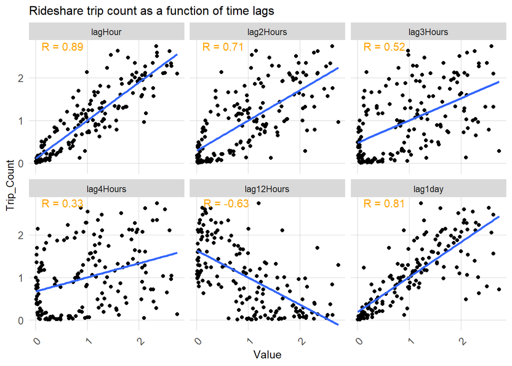

```r
plotData.lag <-
  as.data.frame(ride.panel) %>%
  filter(week == 27) %>%
  group_by(interval60) %>%
    summarise_at(vars(starts_with("lag"), "Trip_Count"), mean, na.rm = TRUE) %>%
    gather(Variable, Value, -interval60, -Trip_Count) %>%
    mutate(Variable = factor(Variable, levels=c("lagHour","lag2Hours","lag3Hours","lag4Hours",
                                                "lag12Hours","lag1day")))

correlation.lag <-
  plotData.lag %>%
  group_by(Variable) %>%
  summarize(correlation = round(cor(Value, Trip_Count),2))

ggplot(data = plotData.lag, aes(Value, Trip_Count)) +
  geom_point() +
  geom_smooth(method = "lm", se = F) +
  facet_wrap(~Variable) +
  geom_text(data=correlation.lag, aes(label=paste("R =", correlation)),colour = "orange", x = -Inf, y = Inf, hjust = -0.3, vjust = 1.2) +
  labs(title = "Rideshare trip count as a function of time lags"
       ) +
  plotTheme
```

### 3.2 Trip variation cross space

The figure below shows the origins of bike trips. It concentrated in the city center area and decreasing in the surrounding area.

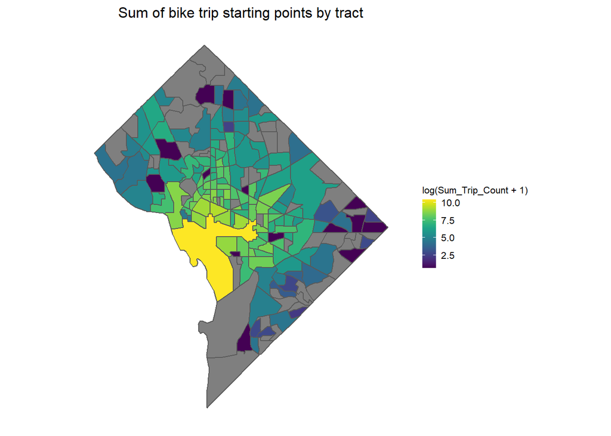

```r
Origin_trip <-
  ride.panel %>%
  group_by(Origin.Tract) %>%
  summarize(Sum_Trip_Count = sum(Trip_Count)) %>%
  st_drop_geometry() %>%
  rename(GEOID = Origin.Tract)

ggplot(DC_tracts %>%
         left_join(Origin_trip, by = "GEOID")) +
  geom_sf(aes(fill = log(Sum_Trip_Count + 1))) +
  scale_fill_viridis() +
  labs(title="Sum of bike trip starting points by tract") +
  mapTheme()
```

The figure below is grouped by stations, time preiod and weekdays.

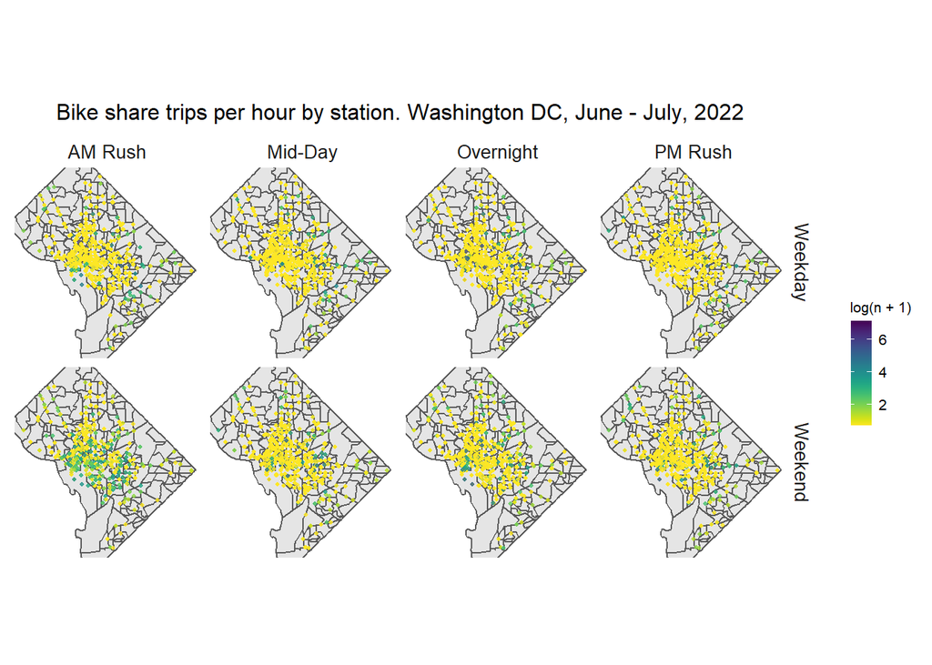

```r
ggplot()+
  geom_sf(data = DC_tracts %>%
          st_transform(crs=4326))+
  geom_point(data = DC_Bike_Census %>%
            mutate(hour = hour(started_at),
                weekend = ifelse(dotw %in% c("Sun", "Sat"), "Weekend", "Weekday"),
                time_of_day = case_when(hour(interval60) < 7 | hour(interval60) > 18 ~ "Overnight",
                                 hour(interval60) >= 7 & hour(interval60) < 10 ~ "AM Rush",
                                 hour(interval60) >= 10 & hour(interval60) < 15 ~ "Mid-Day",
                                 hour(interval60) >= 15 & hour(interval60) <= 18 ~ "PM Rush"))%>%
              group_by(start_station_id, start_lat, start_lng, weekend, time_of_day) %>%
              tally(),
            aes(x = start_lng, y = start_lat, color = log(n + 1)),
            fill = "transparent", alpha = 0.8, size = 0.8)+
  scale_colour_viridis(direction = -1, discrete = FALSE, option = "D")+
  ylim(min(DC_Bike_Census$start_lat), max(DC_Bike_Census$start_lat))+
  xlim(min(DC_Bike_Census$start_lng), max(DC_Bike_Census$start_lng))+
  facet_grid(weekend ~ time_of_day)+
  labs(title="Bike share trips per hour by station. Washington DC, June - July, 2022")+
  mapTheme()
```

### 3.3 Animated map

Then, we chose one week in June, 2022 and made an animation of the rideshare changes. The interval is 15 minutes.

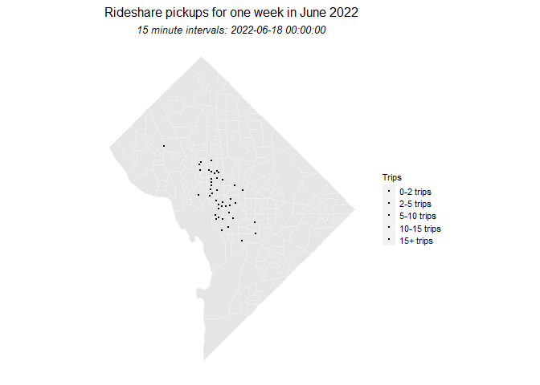

```r
## Animation

week25 <-
  filter(DC_Bike_Census, week == 25)

week25.panel <-
  expand.grid(
    interval15 = unique(week25$interval15),
    Pickup.Census.Tract = unique(DC_Bike_Census$start_station_id))

ride.animation.data <-
  mutate(week25, Trip_Counter = 1) %>%
  select(interval15, start_station_id, start_lng, start_lat, Trip_Counter) %>%
  group_by(interval15, start_station_id, start_lng, start_lat) %>%
  summarize(Trip_Count = sum(Trip_Counter, na.rm=T)) %>%
  ungroup() %>%
  mutate(Trips = case_when(Trip_Count == 0 ~ "0 trips",
                           Trip_Count > 0 & Trip_Count <= 2 ~ "0-2 trips",
                           Trip_Count > 2 & Trip_Count <= 5 ~ "2-5 trips",
                           Trip_Count > 5 & Trip_Count <= 10 ~ "5-10 trips",
                           Trip_Count > 10 & Trip_Count <= 15 ~ "10-15 trips",
                           Trip_Count > 15 ~ "15+ trips")) %>%
  mutate(Trips  = fct_relevel(Trips, "0 trips","0-2 trips","2-5 trips",
                              "5-10 trips","10-15 trips","15+ trips"))

rideshare_animation <-
  ggplot()+
  geom_sf(data = DC_tracts %>%
            st_transform(crs=4326), colour = '#efefef')+
  geom_point(data = ride.animation.data,
             aes(x = start_lng, y = start_lat, fill = Trips), size = 0.5, alpha = 1.5) +
  scale_colour_manual(values = palette5) +
  labs(title = "Rideshare pickups for one week in June 2022",
       subtitle = "15 minute intervals: {current_frame}") +
  transition_manual(interval15) +
  mapTheme()

animate(rideshare_animation, duration=20, renderer = gifski_renderer())
```

## 4. Modeling and validation

### 4.1 Traning set and test set

```r
ride.Train <- filter(ride.panel, week <= 25)
ride.Test <- filter(ride.panel, week > 25)
```

### 4.2 Prediction Model

In this section, we made 5 regression models. The first regression just considered time effects, which includes hour, day of week and temperature. The second one replaces the time fixed effects with start station name. We choose the station as the basic unit. The third one includes both time and space effects. The fourth regression adds the time lag features. And the last regression adds urban facilities data like bus stations, parks, universities and so on.

```r
# 5 Models
reg1 <-
  lm(Trip_Count ~  hour(interval60) + dotw + Temperature,  data=ride.Train)

reg2 <-
  lm(Trip_Count ~  start_station_name + dotw + Temperature,  data=ride.Train)

reg3 <-
  lm(Trip_Count ~  start_station_name + hour(interval60) + dotw + Temperature + Precipitation,
     data=ride.Train)

reg4 <-
  lm(Trip_Count ~  start_station_name +  hour(interval60) + dotw + Temperature + Precipitation +
       lagHour + lag2Hours +lag3Hours + lag12Hours + lag1day,
     data=ride.Train)

reg5 <-
  lm(Trip_Count ~  start_station_name +  hour(interval60) + dotw + Temperature + Precipitation + lagHour + lag2Hours +lag3Hours + lag12Hours + lag1day + park_dist + stop_dist + university_dist,
     data=ride.Train)
```

### 4.3 Validate test set by time

We plotted the MAEs of different models for test set. From the figure below, we can find that the urban facilities factors can not improve model performance. Thus, we won’t use urban facilities factors as predictors for following research.

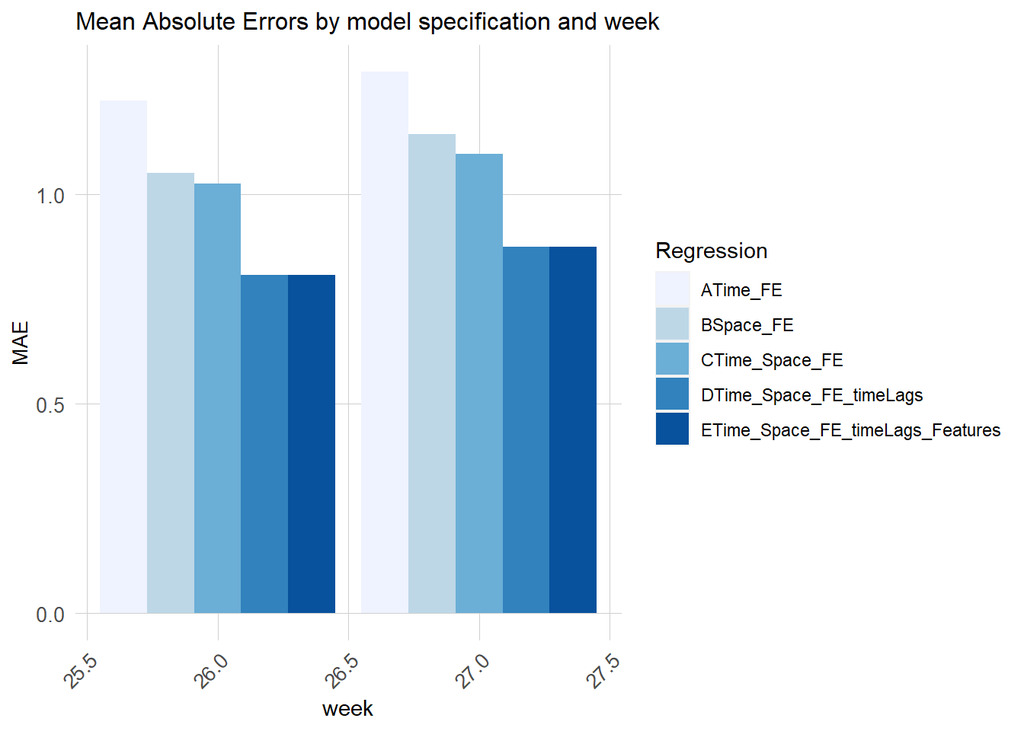

```r
# Predicting
ride.Test.weekNest <-
  ride.Test %>%
  nest(-week)

model_pred <- function(dat, fit){
  pred <- predict(fit, newdata = dat)}

week_predictions <-
  ride.Test.weekNest %>%
  mutate(ATime_FE = map(.x = data, fit = reg1, .f = model_pred),
         BSpace_FE = map(.x = data, fit = reg2, .f = model_pred),
         CTime_Space_FE = map(.x = data, fit = reg3, .f = model_pred),
         DTime_Space_FE_timeLags = map(.x = data, fit = reg4, .f = model_pred),
         ETime_Space_FE_timeLags_Features = map(.x = data, fit = reg5, .f = model_pred)) %>%
  gather(Regression, Prediction, -data, -week) %>%
  mutate(Observed = map(data, pull, Trip_Count),
         Absolute_Error = map2(Observed, Prediction,  ~ abs(.x - .y)),
         MAE = map_dbl(Absolute_Error, mean, na.rm = TRUE),
         sd_AE = map_dbl(Absolute_Error, sd, na.rm = TRUE))

week_predictions %>%
  dplyr::select(week, Regression, MAE) %>%
  gather(Variable, MAE, -Regression, -week) %>%
  ggplot(aes(week, MAE)) +
    geom_bar(aes(fill = Regression), position = "dodge", stat="identity") +
    scale_fill_manual(values = palette5) +
    labs(title = "Mean Absolute Errors by model specification and week") +
  plotTheme
```

We also plotted the predicted and observed bike trips in time series. We can see that with more features, the performance is getting better. Also, the urban facilities failed to make any progress to the model. But it still has some limitations, such as it’s not so accurate in peak travel time.

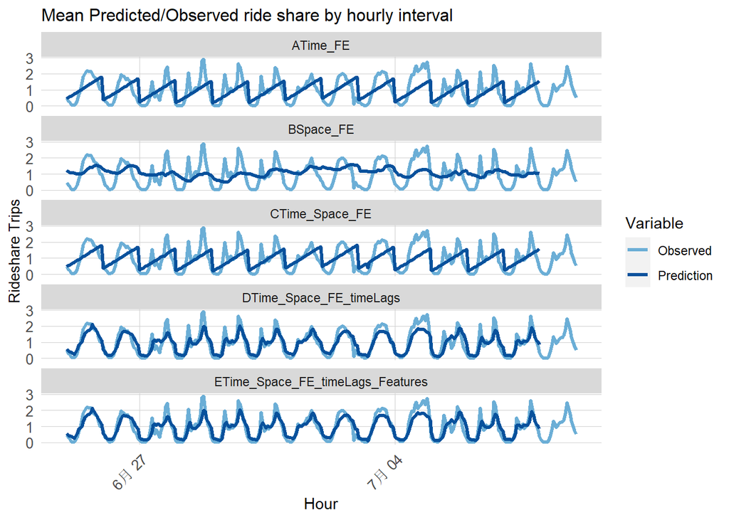

```r
week_predictions %>%
  mutate(interval60 = map(data, pull, interval60),
         Pickup.Census.Tract = map(data, pull, Origin.Tract)) %>%
  dplyr::select(interval60, Pickup.Census.Tract, Observed, Prediction, Regression) %>%
  unnest() %>%
  gather(Variable, Value, -Regression, -interval60, -Pickup.Census.Tract) %>%
    group_by(Regression, Variable, interval60) %>%
    summarize(Value = mean(Value)) %>%
    ggplot(aes(interval60, Value, colour=Variable)) + geom_line(size = 1.1) +
      facet_wrap(~Regression, ncol=1) +
      scale_colour_manual(values = palette2) +
      labs(title = "Mean Predicted/Observed ride share by hourly interval",
           x = "Hour", y= "Rideshare Trips") +
      plotTheme
```

### 4.4 Validate test set by space

The figure below is the MAE of regression 4 by the unit of station. It can display the relationship between error and spatial context. The highest error happens in the downtown area, where most trips start from.

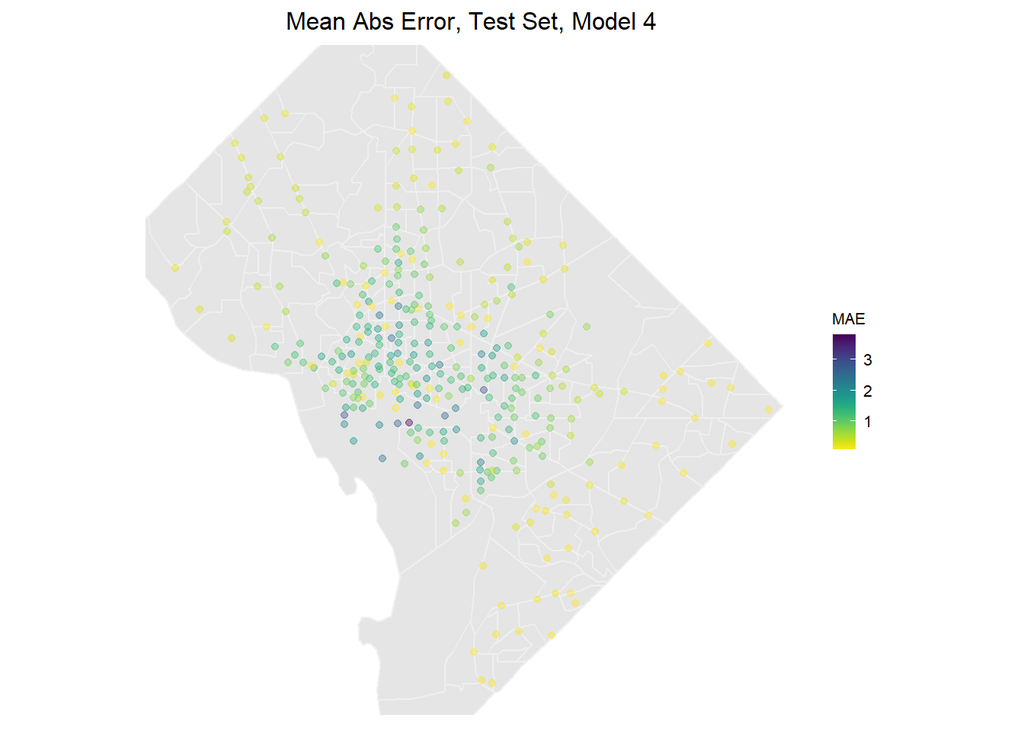

```r
# MAE by stations

week_predictions %>%
  mutate(interval60 = map(data, pull, interval60),
         start_station_id = map(data, pull, start_station_id),
         start_lat = map(data, pull, start_lat),
         start_lng = map(data, pull, start_lng)) %>%
  select(interval60, start_station_id, start_lng, start_lat, Observed, Prediction, Regression) %>%
  unnest() %>%
  filter(Regression == "DTime_Space_FE_timeLags") %>%
  group_by(start_station_id, start_lng, start_lat) %>%
  summarize(MAE = mean(abs(Observed-Prediction), na.rm = TRUE))%>%
  ggplot(.)+
  geom_sf(data = DC_tracts %>%
            st_transform(crs=4326), colour = '#efefef')+
  geom_point(aes(x = start_lng, y = start_lat, color = MAE),
             fill = "transparent", alpha = 0.4)+
  scale_colour_viridis(direction = -1,
                       discrete = FALSE, option = "D")+
  ylim(min(DC_Bike_Census$start_lat), max(DC_Bike_Census$start_lat))+
  xlim(min(DC_Bike_Census$start_lng), max(DC_Bike_Census$start_lng))+
  labs(title="Mean Abs Error, Test Set, Model 4")+
  mapTheme()
```

Then, we check whether the error is related to time period factors. It seems that the errors in weekdays are higher than that in weekends, since the trips are more in weekdays. It’s similar to observe from AM Rush to PM Rush. We can also plot the changes in space.

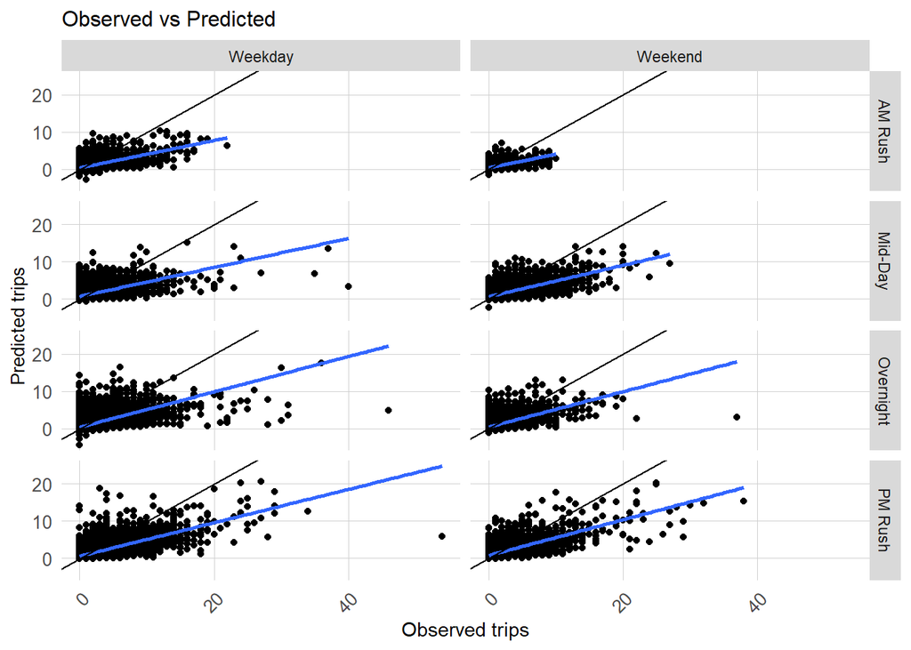

```r
## Scatterplot
week_predictions %>%
  mutate(interval60 = map(data, pull, interval60),
         start_station_id = map(data, pull, start_station_id),
         start_lat = map(data, pull, start_lat),
         start_lng = map(data, pull, start_lng),
         dotw = map(data, pull, dotw)) %>%
  select(interval60, start_station_id, start_lng,
         start_lat, Observed, Prediction, Regression,
         dotw) %>%
  unnest() %>%
  filter(Regression == "DTime_Space_FE_timeLags")%>%
  mutate(weekend = ifelse(dotw %in% c("Sun", "Sat"), "Weekend", "Weekday"),
         time_of_day = case_when(hour(interval60) < 7 | hour(interval60) > 18 ~ "Overnight",
                                 hour(interval60) >= 7 & hour(interval60) < 10 ~ "AM Rush",
                                 hour(interval60) >= 10 & hour(interval60) < 15 ~ "Mid-Day",
                                 hour(interval60) >= 15 & hour(interval60) <= 18 ~ "PM Rush"))%>%
  ggplot()+
  geom_point(aes(x= Observed, y = Prediction))+
  geom_smooth(aes(x= Observed, y= Prediction), method = "lm", se = FALSE)+
  geom_abline(slope = 1, intercept = 0)+
  facet_grid(time_of_day~weekend)+
  labs(title="Observed vs Predicted",
       x="Observed trips",
       y="Predicted trips")+
  plotTheme
```

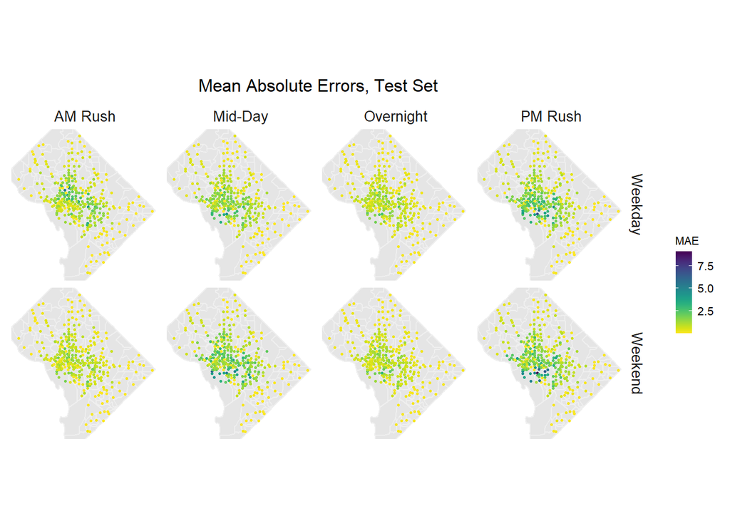

```r
# By hour
week_predictions %>%
  mutate(interval60 = map(data, pull, interval60),
         start_station_id = map(data, pull, start_station_id),
         start_lat = map(data, pull, start_lat),
         start_lng = map(data, pull, start_lng),
         dotw = map(data, pull, dotw) ) %>%
  select(interval60, start_station_id, start_lng,
         start_lat, Observed, Prediction, Regression,
         dotw) %>%
  unnest() %>%
  filter(Regression == "DTime_Space_FE_timeLags")%>%
  mutate(weekend = ifelse(dotw %in% c("Sun", "Sat"), "Weekend", "Weekday"),
         time_of_day = case_when(hour(interval60) < 7 | hour(interval60) > 18 ~ "Overnight",
                                 hour(interval60) >= 7 & hour(interval60) < 10 ~ "AM Rush",
                                 hour(interval60) >= 10 & hour(interval60) < 15 ~ "Mid-Day",
                                 hour(interval60) >= 15 & hour(interval60) <= 18 ~ "PM Rush")) %>%
  group_by(start_station_id, weekend, time_of_day, start_lng, start_lat) %>%
  summarize(MAE = mean(abs(Observed-Prediction), na.rm = TRUE))%>%
  ggplot(.)+
  geom_sf(data = DC_tracts %>%
            st_transform(crs=4326), colour = '#efefef')+
  geom_point(aes(x = start_lng, y = start_lat, color = MAE),
             fill = "transparent", size = 0.5, alpha = 1.5)+
  scale_colour_viridis(direction = -1,
                       discrete = FALSE, option = "D")+
  ylim(min(DC_Bike_Census$start_lat), max(DC_Bike_Census$start_lat))+
  xlim(min(DC_Bike_Census$start_lng), max(DC_Bike_Census$start_lng))+
  facet_grid(weekend~time_of_day)+
  labs(title="Mean Absolute Errors, Test Set")+
  mapTheme()
```

### 4.5 Cross Validation

We conducted the cross validation to test the generalizability of the model. We took a sample of the data and run a 100 k-fold validation on it. We just take 100000 trips data as the sample, since it will take too long to run if you take too much data. From the result, we can know that the MAE is 0.83 which is quite low.

```r
bikenetsample <- sample_n(ride.panel, 100000)%>%
  na.omit()

fitControl <- trainControl(method = "cv",
                           number = 100,
                           savePredictions = TRUE)

set.seed(1000)
# for k-folds CV

reg.cv <-
  train(Trip_Count ~ start_station_name +  hour(interval60) + dotw + Temperature + Precipitation + lagHour + lag2Hours +lag3Hours + lag12Hours + lag1day,
        data = bikenetsample,
        method = "lm",
        trControl = fitControl,
        na.action = na.pass)
reg.cv
```

```
## Linear Regression
##
## 96661 samples
##    11 predictor
##
## No pre-processing
## Resampling: Cross-Validated (100 fold)
## Summary of sample sizes: 95694, 95694, 95694, 95694, 95694, 95694, ...
## Resampling results:
##
##   RMSE      Rsquared  MAE
##   1.526865  0.467141  0.8329598
##
## Tuning parameter 'intercept' was held constant at a value of TRUE
```

## 5. Conclusion

We can find that from the space perspective, the bike share demand is highest in the city center and decreases in all directions through the maps. From the time perspective, in the morning or midnight, the demand is much smaller than the daily time. There are significant differences between the weekdays and weekends.

As far as I’m concerned, the algorithm is useful to some extent due to the low MAE. But it still has some limitations. The model didn’t perform well in the downtown area, may be due to the large number of trips.

To improve our model, here are two suggestions:

- Changing the time lags methods to LSTM which uses the whole sequences of data rather than some lags.
- Use more data to train rather than three weeks.